[O’Hara on GitHub](https://github.com/oharac)

# Compare cumulative impacts per species to IUCN status

Compiled on Sun Feb 13 15:54:11 2022 by ohara

```r
knitr::opts_chunk$set(echo = TRUE, message = FALSE, warning = FALSE)

library(raster)
library(tidyverse)
library(here)
library(RColorBrewer)
library(oharac)
source(here('common_fxns.R'))

library(caret)
library(randomForest)
library(Boruta)
```

# 1 Summary

Compare the relative CHI across species ranges (by stressor and for full range vs. coastal-only range) to spp IUCN Red List threatened status. The relative impact is effectively the average impact per km<sup>2</sup> across the species’ range.

Perform a regression of IUCN extinction risk classification as a function of relative overall CHI and overall range, and then do the same for coastal.

Some refs used for learning random forest etc:

- parameter tuning (mtry parameter): https://machinelearningmastery.com/tune-machine-learning-algorithms-in-r/
- understanding kappa: https://stats.stackexchange.com/questions/82162/cohens-kappa-in-plain-english

# 2 Data

- Species impact scores from script 5
- IUCN extinction risk scores from IUCN

# 3 Methods

## 3.1 Read in species impacts for those spp assessed by IUCN; summarize to CHI

Summarize to cumulative impacts by entire range and by coastal range.

Each file has a row for each stressor-vulnerability match; columns are:

- `str_vuln` (chr): name of stressor/vuln combo, as -
- `impact_tot` (dbl): sum across all cells of stressor intensity $\times$ vulnerability $\times$ ocean area
- `impact_coastal` (dbl): sum across all coastal cells (≤200m) of stressor intensity $\times$ vulnerability $\times$ ocean area
- `range_tot_km2` (dbl): sum of ocean area of all cells across entire range
- `range_coastal_km2` (dbl): sum of ocean area of all cells across coastal range

```r
spp_chi_file <- here_anx('int/spp_chi_summary.csv')

if(!file.exists(spp_chi_file)) {
  spp_imp_fs <- list.files(here_anx('impacts_by_species'),
                           pattern = '^impacts_.+.csv', full.names = TRUE)

  spp_imp_df <- parallel::mclapply(spp_imp_fs, mc.cores = 40,
                                   read_csv, show_col_types = FALSE) %>%
    setNames(basename(spp_imp_fs)) %>%
    bind_rows(.id = 'f')

  spp_ranges <- spp_imp_df %>%
    select(f, range_km2, range) %>%
    distinct() %>%
    spread(range, range_km2) %>%
    rename(range_cst_km2 = coastal, range_tot_km2 = full)

  iucn_worms_lookup <- read_csv(here('_data/iucn_spp', 'iucn_to_worms_match.csv'))

  spp_impacts_df <- spp_imp_df %>%
    select(-range_km2) %>%
    spread(range, impact_tot) %>%
    rename(impact_tot = full, impact_cst = coastal) %>%
    left_join(spp_ranges, by = 'f') %>%
    ### extract species and map info from filename
    mutate(map_src = str_extract(f, '_iucn_|_am_') %>% str_remove_all('_'),
           iucn_sid = str_extract(f, '[0-9]+') %>% as.integer(),
           spp_from_f = str_remove_all(f, 'impacts_(am|iucn)_|.csv')) %>%
    left_join(iucn_worms_lookup, by = 'iucn_sid') %>%
    mutate(sciname = ifelse(is.na(worms_name),
                            str_replace_all(spp_from_f, '_', ' '),
                            worms_name)) %>%
    select('sciname', 'iucn_sid', 'map_src', 'vuln', 'stressor',
           'impact_cst', 'impact_tot', 'range_cst_km2', 'range_tot_km2') %>%
    distinct() %>%
    filter(range_tot_km2 > 0 & !is.na(impact_tot))

  write_csv(spp_impacts_df, spp_chi_file)
}
```

### 3.1.1 Assemble IUCN Red List categories for species in IUCN maps and AquaMaps maps

```r
worms_taxa <- assemble_worms() %>%
  select(sciname = species, phylum, class, order) %>%
  distinct()

iucn_worms_lookup <- read_csv(here('_data/iucn_spp', 'iucn_to_worms_match.csv'))

iucn_assessed <- read_csv(here('_data/iucn_spp/iucn_marine_spp_info_2021-3.csv')) %>%
  select(iucn_sid, cat, cat_score) %>%
  left_join(iucn_worms_lookup, by = 'iucn_sid') %>%
  mutate(threatened = cat %in% c('vu', 'en', 'cr', 'ex'),
         atrisk     = cat %in% c('nt', 'vu', 'en', 'cr', 'ex')) %>%
  select(iucn_sid, iucn_sciname = sciname, sciname = worms_name, cat, cat_score, threatened, atrisk)
iucn_mapped <- read_csv(here('_data/iucn_spp/spp_marine_maps_2021-3.csv'))

assessed_in_am <- get_am_spp_info() %>%
  select(am_sid, am_sciname, sciname, iucn_sid) %>%
  inner_join(iucn_assessed %>%
               select(iucn_sid, cat, threatened, atrisk) %>% distinct(),
             by = 'iucn_sid') %>%
  select(sciname, cat, threatened, atrisk) %>%
  distinct() %>%
  mutate(map_src = 'am',
         iucn_sid = -1)

assessed_in_iucn_maps <- iucn_assessed %>%
  filter(iucn_sid %in% iucn_mapped$iucn_sid) %>%
  select(sciname, iucn_sid, cat, threatened, atrisk) %>%
  distinct() %>%
  mutate(map_src = 'iucn')

assessed_df <- bind_rows(assessed_in_am, assessed_in_iucn_maps) %>%
  group_by(sciname) %>%
  filter(n() == 1 | map_src == 'iucn') %>%
  left_join(worms_taxa, by = 'sciname') %>%
  filter(cat != 'dd') %>%
  filter(!is.na(class))
```

```r
mapped_df <- get_am_spp_info() %>%
  select(am_sid, am_sciname, sciname, iucn_sid, iucn_code) %>%
  left_join(iucn_assessed %>%
               select(iucn_sid, cat, threatened, atrisk) %>% distinct(),
             by = c('iucn_sid')) %>%
  bind_rows(assessed_in_iucn_maps) %>%
  group_by(sciname) %>%
  filter(n() == 1 | map_src == 'iucn') %>%
  left_join(worms_taxa, by = 'sciname') %>%
  mutate(tx = case_when(phylum == 'chordata' ~ class,
                        class %in% c('cephalopoda', 'malacostraca') ~ class,
                        TRUE ~ phylum))

mapped_spp_summary <- mapped_df %>%
  select(iucn_sid, sciname, cat, iucn_code, threatened, tx) %>%
  mutate(status = case_when(threatened        ~ 'threatened',
                            !threatened       ~ 'not threatened',
                            cat == 'dd'       ~ 'data deficient',
                            iucn_code %in% c('cr', 'en', 'ex', 'vu') ~ 'threatened',
                            iucn_code %in% c('lc', 'nt', 'lr/cd', 'lr/lc', 'lr/nt') ~ 'not threatened',
                            iucn_code == 'dd' ~ 'data deficient',
                            iucn_code == 'n.e.' ~ 'not evaluated',
                            TRUE ~ 'not evaluated')) %>%
  distinct() %>%
  group_by(tx, status) %>%
  summarize(n_spp = n())
```

### 3.1.2 Combine IUCN categories with impacts

```r
iucn_impacts_df <- read_csv(spp_chi_file) %>%
  mutate(iucn_sid = ifelse(is.na(iucn_sid), -1, iucn_sid)) %>%
  inner_join(assessed_df, by = c('sciname', 'iucn_sid', 'map_src')) %>%
  mutate(iucn_fct = toupper(cat),
         iucn_fct = factor(iucn_fct, levels = c('LC', 'NT', 'VU', 'EN', 'CR', 'EX'))) %>%
  select(-iucn_sid, -map_src) %>%
  arrange(stressor, vuln)
```

## 3.2 Set up dataframe for coastal impacts and full range impacts

Calculate coastal impacts by vulnerability category - for categories like bycatch and habitat loss that map to multiple stressor layers, sum the impacts for all sources prior to calculating relative impact.

Alternately, what if we go stressor layer by stressor layer?

```r
phl_vec <- c('arthropoda', 'chordata', 'cnidaria', 'echinodermata', 'mollusca')
cls_vec <- c('actinopterygii', 'anthozoa', 'aves', 'bivalvia',
             'cephalopoda', 'echinoidea', 'elasmobranchii', 'gastropoda',
             'holothuroidea', 'malacostraca', 'mammalia', 'myxini', 'reptilia')

taxon_gps <- iucn_impacts_df %>%
  select(phylum, class) %>%
  distinct() %>%
  mutate(tx = case_when(phylum == 'chordata' ~ class,
                        class %in% c('cephalopoda', 'malacostraca') ~ class,
                        TRUE ~ phylum))
```

```r
cst_impacts_df <- iucn_impacts_df %>%
  group_by(sciname, stressor, range_cst_km2, threatened, phylum, class, order) %>%
  summarize(imp_sum = sum(impact_cst), .groups = 'drop') %>%
  filter(range_cst_km2 > 0) %>%
  mutate(rel_impact = imp_sum / range_cst_km2,
         inv_ln_range = 1/log(range_cst_km2),
         threatened = factor(threatened)) %>%
  select(-range_cst_km2, -imp_sum) %>%
  pivot_wider(names_from = stressor, values_from = rel_impact, values_fill = 0) %>%
  left_join(taxon_gps, by = c('phylum', 'class')) %>%
  distinct()

full_range_impacts_df <- iucn_impacts_df %>%
  group_by(sciname, stressor, range_tot_km2, threatened, phylum, class, order) %>%
  summarize(imp_sum = sum(impact_tot), .groups = 'drop') %>%
  filter(range_tot_km2 > 0) %>%
  mutate(rel_impact = imp_sum / range_tot_km2,
         inv_ln_range = 1/log(range_tot_km2),
         threatened = factor(threatened)) %>%
  select(-range_tot_km2, -imp_sum) %>%
  pivot_wider(names_from = stressor, values_from = rel_impact, values_fill = 0) %>%
  left_join(taxon_gps, by = c('phylum', 'class')) %>%
  distinct()
```

Subset species impacts by taxonomic group. Rather than set aside a test for post-RF, run a repeated k-fold cross validation on each entire taxon. Use a typical default of 10 folds, and 10 repeats, per https://machinelearningmastery.com/repeated-k-fold-cross-validation-with-python.

#### 3.2.0.1 Species inclusion: coastal only

```r
cst_impacts_df %>% select(tx, threatened) %>% table()
```

```
##                 threatened
## tx               FALSE TRUE
##   actinopterygii  6284  231
##   aves             221   90
##   cephalopoda      208    4
##   cnidaria         467  230
##   echinodermata     69   13
##   elasmobranchii   584  381
##   malacostraca     161    2
##   mammalia          84   53
##   mollusca         550   71
##   myxini            36    9
##   reptilia          54   19
```

#### 3.2.0.2 Species inclusion: full range

```r
full_range_impacts_df %>% select(tx, threatened) %>% table()
```

```
##                 threatened
## tx               FALSE TRUE
##   actinopterygii  6286  231
##   aves             221   90
##   cephalopoda      208    4
##   cnidaria         467  230
##   echinodermata     69   13
##   elasmobranchii   605  381
##   malacostraca     162    2
##   mammalia          84   53
##   mollusca         550   71
##   myxini            37    9
##   reptilia          54   19
```

### 3.2.1 Function to calculate random forest results

#### 3.2.1.1 Boruta to identify important attributes

Function to use Boruta algorithm to identify important attributes for a given dataframe and regression formula, and rough-fix any tentatively important variables. Returns a vector of verified important attributes (stressor names).

```r
get_important_vars <- function(df, formula) {

  boruta_train <- Boruta(formula = formula, data = df) %>%
    TentativeRoughFix()
  # print(boruta_train)

  strs_selected <- getSelectedAttributes(boruta_train, withTentative = F)

  message('Identified ', length(strs_selected), ' important attributes:\n  ', paste0(strs_selected, collapse = ';'))
  # bank_df <- attStats(boruta_spp)
  # print(bank_df)
  return(strs_selected)
}
```

#### 3.2.1.2 Iterate to estimate marginal effect

based on https://stackoverflow.com/questions/64388396/random-forest-variable-importance-and-direction-of-correlation-for-binomial-resp

```r
calc_direction <- function(df, mdl) {
  ### df <- spp_train
  att_names <- names(df %>% select(-threatened))

  res <- data.frame()
  for(i in 1:length(att_names)){ ### i <- 1

    att <- att_names[i]
    ### predict based on original data
    p1 <- predict(mdl, newdata = df, type = "prob")

    ### predict based on original data with one column increased by 1 sd
    df2 <- df
    df2[[att]] <- df2[[att]] + sd(df2[[att]])
    p2 <- predict(mdl, newdata = df2, type = "prob")

    ### find the difference
    diff <- (p2 - p1)[, 2]
    res_tmp <- data.frame(att,
                          mean_effect = mean(diff),
                          sd_effect   = sd(diff))
    res <- bind_rows(res, res_tmp)
  }

  return(res)
}
```

For a given dataframe, set up the training parameters according to number of included columns (minus one, which is threatened status T/F). Try several mtry values; identify mtry with highest accuracy and kappa. Bind to that, the importance of each variable.

Return a dataframe of: best mtry, accuracy, and kappa; then relative importance of each included variable.

```r
calc_rand_forest <- function(df) {

  ### regress threatened status against all predictors
  form1 <- threatened ~ .

  message('Applying Boruta algorithm to identify important attributes...')
  strs_selected <- get_important_vars(formula = form1, df = df)

  spp_train <- df %>%
    ### in case no important predictor vars, at least include range
    select(threatened, inv_ln_range, all_of(strs_selected))
  n_preds <- ncol(spp_train) - 1

  ### set up train control for n-repeated k-fold cross-validation
  k <- 10; repeats <- 10
  message('Setting up repeated ', k, '-fold cross validation with ', repeats, ' repeats...')
  tr_ctrl <- trainControl(method = 'repeatedcv', number = k, repeats = repeats)
  ### set up a tunegrid to step by three, up to all included predictors
  tunegrid <- data.frame(.mtry = c(seq(min(n_preds, 2), n_preds, 3), n_preds) %>% unique())

  # system.time({
    mdl <- train(form = form1,
                 data = spp_train,
                 method = 'rf',
                 tuneGrid = tunegrid,
                 trControl = tr_ctrl)
  # })

  rf_out <- mdl$results %>%
    janitor::clean_names() %>%
    filter(accuracy == max(accuracy)) %>%
    filter(kappa == max(kappa)) %>%
      ### sometimes identical accuracy for different mtry - in which case,
      ### select the one with better kappa (sequential, not simultaneous)
    mutate(acc_exp = (accuracy - kappa) / (1 - kappa))

  message('Calculating attribute importance...')
  pred_importance <- varImp(mdl)$importance %>%
    rename(importance = Overall) %>%
    mutate(stressor = row.names(.)) %>%
    mutate(stressor = str_remove(stressor, '_[0-9]{4}'))

  message('Calculating attribute effect direction...')
  effect_dir <- calc_direction(spp_train, mdl) %>%
    mutate(att = str_remove(att, '_[0-9]{4}'))

  out_df <- cbind(rf_out, pred_importance) %>%
    full_join(effect_dir, by = c('stressor' = 'att'))

  return(out_df)
}
```

### 3.2.2 Iterate over taxa: coastal only

```r
taxa <- taxon_gps$tx %>% unique() %>% sort()
set.seed(42)

tmp <- parallel::mclapply(taxa, mc.cores = 11,
          FUN = function(taxon) { ### taxon <- taxa[8]
            tmp_f <- sprintf(here('tmp/rand_forest_results_coastal_%s.csv'), taxon)
            if(!file.exists(tmp_f)) {
              ### set.seed(151)
              df <- cst_impacts_df %>%
                filter(tx == taxon) %>%
                select(-sciname, -phylum, -class, -tx, -where(is.character))

              rf_results <- calc_rand_forest(df) %>%
                mutate(taxon = taxon)
              write_csv(rf_results, tmp_f)
            }
          })

rf_result_fs <- list.files(here('tmp'), pattern = 'rand_forest_results_coastal', full.names = TRUE)
rf_results_coastal <- lapply(rf_result_fs, FUN = read_csv, show_col_types = FALSE) %>%
  bind_rows() %>%
  mutate()

DT::datatable(rf_results_coastal)
```

|  | mtry | accuracy | kappa | accuracy_sd | kappa_sd | acc_exp | importance | stressor | mean_effect | sd_effect | taxon |
| --- | --- | --- | --- | --- | --- | --- | --- | --- | --- | --- | --- |
| 1 | 2 | 0.968242197859836 | 0.221442548592177 | 0.00283657734672841 | 0.103271532516178 | 0.959209430103407 | 100 | inv_ln_range | 0.0140613967766692 | 0.0345739617845582 | actinopterygii |
| 2 | 2 | 0.968242197859836 | 0.221442548592177 | 0.00283657734672841 | 0.103271532516178 | 0.959209430103407 | 8.04701273239409 | benth_str | 0.0144690713737529 | 0.0306148399408807 | actinopterygii |
| 3 | 2 | 0.968242197859836 | 0.221442548592177 | 0.00283657734672841 | 0.103271532516178 | 0.959209430103407 | 44.4189876778717 | biomass_removal | 0.0546606293169609 | 0.0519374293659825 | actinopterygii |
| 4 | 2 | 0.968242197859836 | 0.221442548592177 | 0.00283657734672841 | 0.103271532516178 | 0.959209430103407 | 48.4714003102692 | bycatch_benthic | 0.00683837298541826 | 0.0214815999220109 | actinopterygii |
| 5 | 2 | 0.968242197859836 | 0.221442548592177 | 0.00283657734672841 | 0.103271532516178 | 0.959209430103407 | 28.0359265749795 | bycatch_pelagic | 0.0111106676899463 | 0.0236215791258429 | actinopterygii |
| 6 | 2 | 0.968242197859836 | 0.221442548592177 | 0.00283657734672841 | 0.103271532516178 | 0.959209430103407 | 87.8089578115286 | cumulative | 0.0069937068303914 | 0.0331249222822037 | actinopterygii |
| 7 | 2 | 0.968242197859836 | 0.221442548592177 | 0.00283657734672841 | 0.103271532516178 | 0.959209430103407 | 59.9344788852605 | direct_human | 0.00244389869531849 | 0.02876601486908 | actinopterygii |
| 8 | 2 | 0.968242197859836 | 0.221442548592177 | 0.00283657734672841 | 0.103271532516178 | 0.959209430103407 | 45.1171130186481 | fishing_benthic_dest | 0.0157976976208749 | 0.0389329611373259 | actinopterygii |
| 9 | 2 | 0.968242197859836 | 0.221442548592177 | 0.00283657734672841 | 0.103271532516178 | 0.959209430103407 | 38.2421750356254 | light | 0.021608902532617 | 0.0334697299846608 | actinopterygii |
| 10 | 2 | 0.968242197859836 | 0.221442548592177 | 0.00283657734672841 | 0.103271532516178 | 0.959209430103407 | 66.4869275645096 | microplastics | 0.0129952417498081 | 0.0332282392185006 | actinopterygii |

[output cut: 106 more lines]

```r
write_csv(rf_results_coastal, here('_output/iucn_prediction_rf_results_coastal.csv'))
```

### 3.2.3 Iterate over taxa: full range

```r
taxa <- taxon_gps$tx %>% unique() %>% sort()

tmp <- parallel::mclapply(taxa, mc.cores = 11,
          FUN = function(taxon) { ### taxon <- taxa[7]
            tmp_f <- sprintf(here('tmp/rand_forest_results_full_range_%s.csv'), taxon)
            if(!file.exists(tmp_f)) {
              df <- full_range_impacts_df %>%
                filter(tx == taxon) %>%
                select(-sciname, -phylum, -class, -order, -tx, -where(is.character))

              rf_results <- calc_rand_forest(df) %>%
                mutate(taxon = taxon)
              write_csv(rf_results, tmp_f)
            }
          })

rf_result_fs <- list.files(here('tmp'), pattern = 'rand_forest_results_full_range', full.names = TRUE)
rf_results_full_range <- lapply(rf_result_fs, FUN = read_csv, show_col_types = FALSE) %>%
  bind_rows()

DT::datatable(rf_results_full_range)
```

|  | mtry | accuracy | kappa | accuracy_sd | kappa_sd | acc_exp | importance | stressor | mean_effect | sd_effect | taxon |
| --- | --- | --- | --- | --- | --- | --- | --- | --- | --- | --- | --- |
| 1 | 2 | 0.96863597582969 | 0.23556763699478 | 0.00294407808114705 | 0.102220738125339 | 0.958970831576246 | 74.66184825777 | cumulative | 0.00536504526622679 | 0.0319817525794435 | actinopterygii |
| 2 | 2 | 0.96863597582969 | 0.23556763699478 | 0.00294407808114705 | 0.102220738125339 | 0.958970831576246 | 100 | inv_ln_range | 0.0172763541506828 | 0.0384937297800296 | actinopterygii |
| 3 | 2 | 0.96863597582969 | 0.23556763699478 | 0.00294407808114705 | 0.102220738125339 | 0.958970831576246 | 3.61925854141717 | benth_str | 0.02364676998619 | 0.0387641949376396 | actinopterygii |
| 4 | 2 | 0.96863597582969 | 0.23556763699478 | 0.00294407808114705 | 0.102220738125339 | 0.958970831576246 | 35.8676522476998 | biomass_removal | 0.042088691115544 | 0.0470097372731019 | actinopterygii |
| 5 | 2 | 0.96863597582969 | 0.23556763699478 | 0.00294407808114705 | 0.102220738125339 | 0.958970831576246 | 42.6709563449325 | bycatch_benthic | 0.00490808654288783 | 0.0217924734834715 | actinopterygii |
| 6 | 2 | 0.96863597582969 | 0.23556763699478 | 0.00294407808114705 | 0.102220738125339 | 0.958970831576246 | 22.1064687827897 | bycatch_pelagic | 0.0124572656130121 | 0.0224990189693817 | actinopterygii |
| 7 | 2 | 0.96863597582969 | 0.23556763699478 | 0.00294407808114705 | 0.102220738125339 | 0.958970831576246 | 47.9768922052517 | direct_human | 0.00443179377013963 | 0.0246273794079391 | actinopterygii |
| 8 | 2 | 0.96863597582969 | 0.23556763699478 | 0.00294407808114705 | 0.102220738125339 | 0.958970831576246 | 42.2470044424086 | fishing_benthic_dest | 0.0337775049869572 | 0.0462634802451563 | actinopterygii |
| 9 | 2 | 0.96863597582969 | 0.23556763699478 | 0.00294407808114705 | 0.102220738125339 | 0.958970831576246 | 33.2469364418915 | light | 0.0224446831364125 | 0.0322370824136761 | actinopterygii |
| 10 | 2 | 0.96863597582969 | 0.23556763699478 | 0.00294407808114705 | 0.102220738125339 | 0.958970831576246 | 59.4160081590197 | microplastics | 0.0105763388061992 | 0.0324904558669745 | actinopterygii |

[output cut: 107 more lines]

```r
write_csv(rf_results_full_range, here('_output/iucn_prediction_rf_results_full_range.csv'))
```

## 3.3 Visualize results

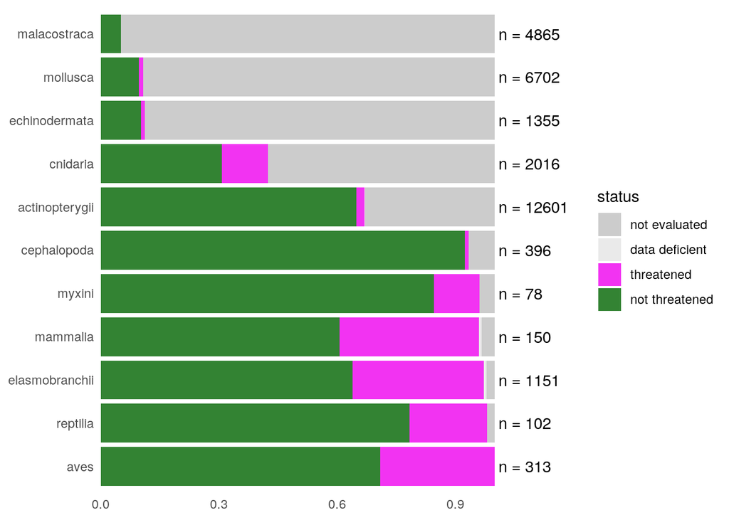

```r
status_lvls <- c('not evaluated', 'data deficient',  'threatened', 'not threatened')
spp_inclusion <- mapped_spp_summary %>%
  filter(tx %in% taxon_gps$tx) %>%
  group_by(tx) %>%
  complete(status = status_lvls, fill = list(n_spp = 0)) %>%
  mutate(n_tot = sum(n_spp),
         pct = n_spp / n_tot,
         status = factor(status, levels = status_lvls)) %>%
  ungroup() %>%
  arrange(status, pct) %>%
  mutate(tx = fct_inorder(tx))

ggplot(spp_inclusion, aes(y = tx)) +
  geom_col(aes(x = pct, fill = status), alpha = .8) +
  scale_fill_manual(values = c('grey75', 'grey90', 'magenta2', 'darkgreen')) +
  geom_text(data = spp_inclusion %>% select(tx, n_tot) %>% distinct(),
            x = 1.01, aes(label = paste0('n = ', n_tot)),
            hjust = 0) +
  scale_x_continuous(limits = c(0, 1.2), expand = c(0, 0)) +
  theme_minimal() +
  theme(axis.title = element_blank(),
        panel.grid = element_blank())
```

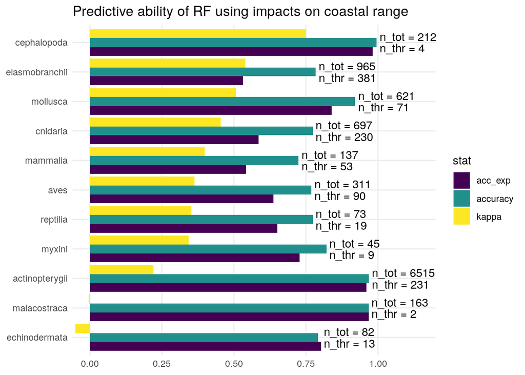

```r
cst_rf_results <- read_csv(here('_output/iucn_prediction_rf_results_coastal.csv'))

cst_nums <- cst_impacts_df %>%
  group_by(tx) %>%
  summarize(n_spp = n(),
            pct_thr = round(100 * sum(threatened == TRUE) / n_spp, 2)) %>%
  ungroup()

cst_imp_sum <- cst_rf_results %>%
  select(accuracy, kappa, acc_exp, taxon) %>%
  mutate(taxon = fct_reorder(taxon, kappa)) %>%
  distinct() %>%
  gather(stat, value, accuracy, kappa, acc_exp)

cst_nums <- cst_impacts_df %>%
  group_by(tx) %>%
  summarize(n_spp = n(),
            n_thr = sum(threatened == TRUE)) %>%
  ungroup() %>%
  mutate(n_spp = sprintf('n_tot = %s', n_spp),
         n_thr = sprintf('n_thr = %s', n_thr)) %>%
  left_join(cst_imp_sum %>%
              group_by(taxon) %>%
              filter(value == max(value)) %>%
              mutate(stat == 'accuracy'),
            by = c('tx' = 'taxon'))

ggplot(cst_imp_sum, aes(x = taxon, y = value, fill = stat)) +
  geom_col(position = 'dodge') +
  geom_text(data = cst_nums, aes(x = tx, y = value, label = n_spp),
            color = 'black',
            hjust = 0, vjust = 0, nudge_x = .05, nudge_y = .01) +
  geom_text(data = cst_nums, aes(x = tx, y = value, label = n_thr),
            color = 'black',
            hjust = 0, vjust = 1, nudge_x = -.05, nudge_y = .01) +
  scale_fill_viridis_d() +
  scale_y_continuous(limits = c(-.06, 1.2), breaks = (0:4)/4, expand = c(0, 0)) +
  coord_flip() +
  theme_minimal() +
  theme(axis.title = element_blank(),
        panel.grid.minor = element_blank()) +
  labs(title = 'Predictive ability of RF using impacts on coastal range')
```

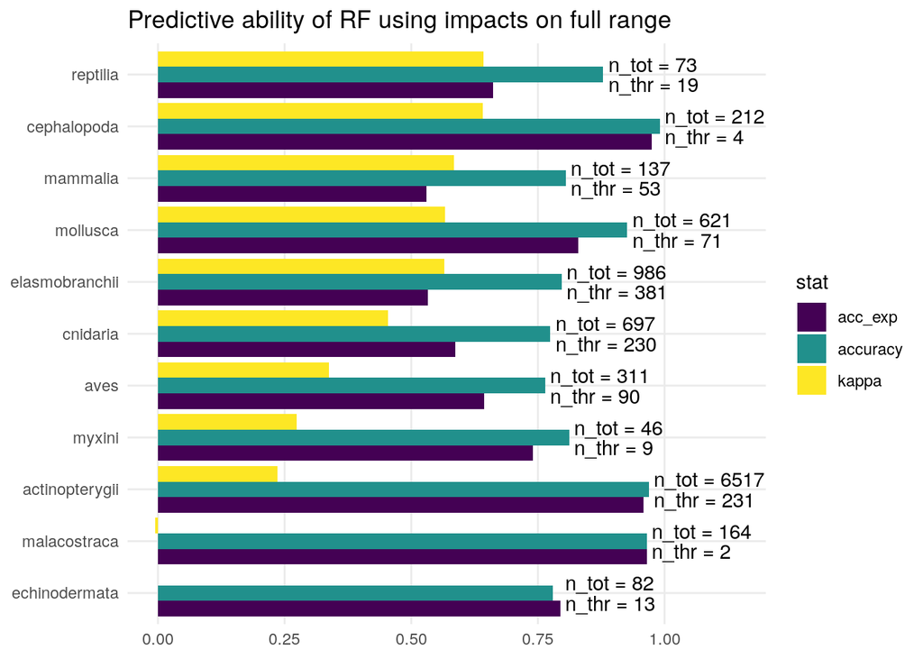

```r
full_rf_results <- read_csv(here('_output/iucn_prediction_rf_results_full_range.csv'))

full_nums <- full_range_impacts_df %>%
  group_by(tx) %>%
  summarize(n_spp = n(),
            pct_thr = round(100 * sum(threatened == TRUE) / n_spp, 2)) %>%
  ungroup()

full_imp_sum <- full_rf_results %>%
  select(accuracy, kappa, acc_exp, taxon) %>%
  mutate(taxon = fct_reorder(taxon, kappa)) %>%
  distinct() %>%
  gather(stat, value, accuracy, kappa, acc_exp)

full_nums <- full_range_impacts_df %>%
  group_by(tx) %>%
  summarize(n_spp = n(),
            n_thr = sum(threatened == TRUE)) %>%
  ungroup() %>%
  mutate(n_spp = sprintf('n_tot = %s', n_spp),
         n_thr = sprintf('n_thr = %s', n_thr)) %>%
  left_join(full_imp_sum %>%
              group_by(taxon) %>%
              filter(value == max(value)) %>%
              mutate(stat == 'accuracy'),
            by = c('tx' = 'taxon'))

ggplot(full_imp_sum, aes(x = taxon, y = value, fill = stat)) +
  geom_col(position = 'dodge') +
  geom_text(data = full_nums, aes(x = tx, y = value, label = n_spp),
            color = 'black',
            hjust = 0, vjust = 0, nudge_x = .05, nudge_y = .01) +
  geom_text(data = full_nums, aes(x = tx, y = value, label = n_thr),
            color = 'black',
            hjust = 0, vjust = 1, nudge_x = -.05, nudge_y = .01) +
  scale_fill_viridis_d() +
  scale_y_continuous(limits = c(-.06, 1.2), breaks = (0:4)/4, expand = c(0, 0)) +
  coord_flip() +
  theme_minimal() +
  theme(axis.title = element_blank(),
        panel.grid.minor = element_blank()) +
  labs(title = 'Predictive ability of RF using impacts on full range')
```